# Navigating Global Trade: An Analysis of Imports and Exports from 1980 to 2022

```python
import pandas as pd
import numpy as np
import matplotlib.pyplot as plt
import seaborn as sns
from statsmodels.tsa.seasonal import seasonal_decompose
from statsmodels.tsa.arima.model import ARIMA
from sklearn.cluster import KMeans
from sklearn.preprocessing import StandardScaler
from scipy import stats
from sklearn.ensemble import IsolationForest
from scipy.stats import zscore
```

```python
df = pd.read_csv("C:/Users/kvsvy/Documents/GitHub/Navigating-Global-Trade--An-Analysis-of-Imports-and-Exports-from-1980-to-2022/WTO STATS FILE.csv", encoding='ISO-8859-1')
df.head()
```

|  | Indicator | Country | Product | Unit | Year | ValueFlag | Value |
| --- | --- | --- | --- | --- | --- | --- | --- |
| 0 | Imports | China | Agricultural products | M$ | 2009 | NaN | 76617 |
| 1 | Imports | China | Agricultural products | M$ | 2007 | NaN | 65369 |
| 2 | Imports | Greenland | Agricultural products | M$ | 1984 | NaN | 59 |
| 3 | Imports | China | Agricultural products | M$ | 2008 | NaN | 86807 |
| 4 | Imports | Cabo Verde | Agricultural products | M$ | 2008 | NaN | 242 |

### Lets understand the dataset before performing analysis!

```python
df.info()
```

```
<class 'pandas.core.frame.DataFrame'>
RangeIndex: 185392 entries, 0 to 185391
Data columns (total 7 columns):
 #   Column     Non-Null Count   Dtype
---  ------     --------------   -----
 0   Indicator  185392 non-null  object
 1   Country    185392 non-null  object
 2   Product    185392 non-null  object
 3   Unit       185392 non-null  object
 4   Year       185392 non-null  int64
 5   ValueFlag  10146 non-null   object
 6   Value      185392 non-null  int64
dtypes: int64(2), object(5)
memory usage: 9.9+ MB
```

```python
print("\nNull values in each column:")
print(df.isnull().sum())
```

```
Null values in each column:
Indicator         0
Country           0
Product           0
Unit              0
Year              0
ValueFlag    175246
Value             0
dtype: int64
```

```python
categorical_columns = ['Indicator', 'Country', 'Product', 'Unit', 'ValueFlag']
for col in categorical_columns:
    print(f"\nUnique values in {col}:")
    print(df[col].value_counts())
```

```
Unique values in Indicator:
Indicator
Imports    94452
Exports    90940
Name: count, dtype: int64

Unique values in Country:
Country
Malaysia                       1282
Thailand                       1282
Japan                          1282
Tunisia                        1282
Australia                      1282
                               ...
Chad                             15
French Southern Territories      10
Equatorial Guinea                 8
Guam                              1
Nauru                             1
Name: count, Length: 208, dtype: int64

Unique values in Product:
Product
Agricultural products                              12974
Manufactures                                       12968
Fuels and mining products                          12841
Food                                               12744
Clothing                                           12560
Textiles                                           12511
Office and telecom equipment                       12256
Chemicals                                          10452
Machinery and transport equipment                  10429
Automotive products                                10295
Iron and steel                                     10274
Fuels                                              10033
Transport equipment                                 9131
Telecommunications equipment                        9106
Electronic data processing and office equipment     9094
Pharmaceuticals                                     8954
Integrated circuits and electronic components       8770
Name: count, dtype: int64

Unique values in Unit:
Unit
M$    185392
Name: count, dtype: int64

Unique values in ValueFlag:
ValueFlag
Estimate           9705
Break in series     441
Name: count, dtype: int64
```

```python
print("\nBasic statistics for numerical columns:")
print(df.describe())
```

```
Basic statistics for numerical columns:
                Year         Value
count  185392.000000  1.853920e+05
mean     2005.802775  1.196078e+04
std        10.880144  8.509800e+04
min      1980.000000  0.000000e+00
25%      1998.000000  2.600000e+01
50%      2007.000000  3.380000e+02
75%      2015.000000  2.856000e+03
max      2022.000000  5.395470e+06
```

#### Unique products

```python
df['Product'].unique()
```

```
array(['Agricultural products', 'Food', 'Manufactures', 'Chemicals',
       'Pharmaceuticals', 'Clothing', 'Iron and steel',
       'Machinery and transport equipment', 'Automotive products',
       'Office and telecom equipment',
       'Electronic data processing and office equipment',
       'Integrated circuits and electronic components',
       'Telecommunications equipment', 'Transport equipment', 'Textiles',
       'Fuels and mining products', 'Fuels'], dtype=object)
```

##### Outliers detection

```python
Q1 = df['Value'].quantile(0.25)
Q3 = df['Value'].quantile(0.75)
IQR = Q3 - Q1
lower_bound = Q1 - 1.5 * IQR
upper_bound = Q3 + 1.5 * IQR
```

```python
print("\nPotential outliers in 'Value' column:")
print(f"Values below {lower_bound:.2f} or above {upper_bound:.2f}")
```

```
Potential outliers in 'Value' column:
Values below -4219.00 or above 7101.00
```

```python
outliers = df[df['Value']>7101]
```

```python
outliers.describe(include='all')
```

|  | Indicator | Country | Product | Unit | Year | ValueFlag | Value |
| --- | --- | --- | --- | --- | --- | --- | --- |
| count | 30242 | 30242 | 30242 | 30242 | 30242.000000 | 838 | 3.024200e+04 |
| unique | 2 | 125 | 17 | 1 | NaN | 2 | NaN |
| top | Imports | United States of America | Manufactures | M$ | NaN | Estimate | NaN |
| freq | 15967 | 1182 | 4840 | 30242 | NaN | 754 | NaN |
| mean | NaN | NaN | NaN | NaN | 2008.462866 | NaN | 6.889496e+04 |
| std | NaN | NaN | NaN | NaN | 9.931638 | NaN | 2.012717e+05 |
| min | NaN | NaN | NaN | NaN | 1980.000000 | NaN | 7.102000e+03 |
| 25% | NaN | NaN | NaN | NaN | 2002.000000 | NaN | 1.177800e+04 |
| 50% | NaN | NaN | NaN | NaN | 2010.000000 | NaN | 2.233700e+04 |
| 75% | NaN | NaN | NaN | NaN | 2017.000000 | NaN | 5.532300e+04 |
| max | NaN | NaN | NaN | NaN | 2022.000000 | NaN | 5.395470e+06 |

```python
outliers['Value'].min(),outliers['Value'].max()
```

```
(7102, 5395470)
```

```python
outliers[outliers['Value']>500000]['Country'].unique()
```

```
array(['European Union', 'China', 'United States of America',
       'United Kingdom', 'Germany', 'Hong Kong, China', 'France',
       'Netherlands', 'Japan', 'Korea, Republic of', 'Italy'],
      dtype=object)
```

```python
outliers[outliers['Value']>500000]['Product'].unique()
```

```
array(['Agricultural products', 'Food', 'Manufactures', 'Chemicals',
       'Machinery and transport equipment', 'Automotive products',
       'Office and telecom equipment', 'Transport equipment',
       'Fuels and mining products', 'Fuels', 'Pharmaceuticals'],
      dtype=object)
```

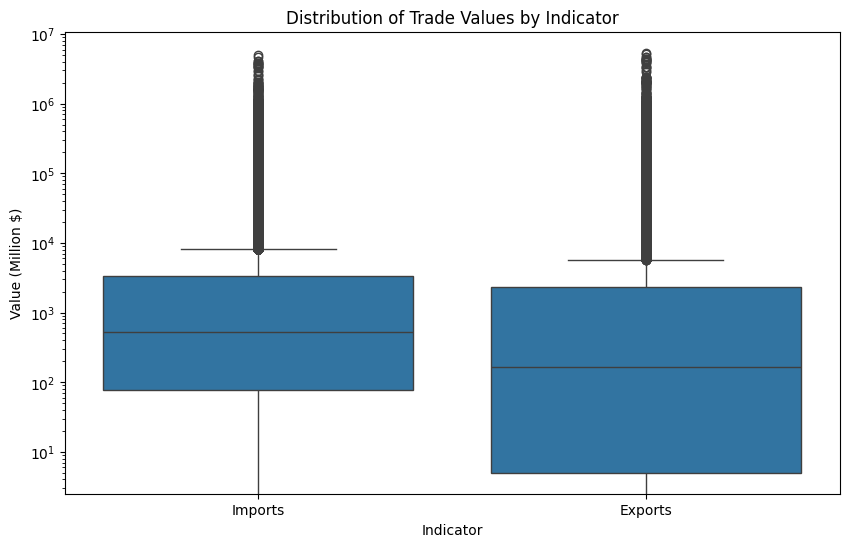

```python
plt.figure(figsize=(10, 6))
sns.boxplot(x='Indicator', y='Value', data=df)
plt.title('Distribution of Trade Values by Indicator')
plt.ylabel('Value (Million $)')
plt.yscale('log')  # Using log scale due to potential large range
plt.show()
```

```python
df[df['Value']<1]['Country'].unique()
```

```
array(['French Southern Territories', 'Belize', 'Tuvalu',
       'Central African Republic', 'Afghanistan', 'Cook Islands',
       'Guinea-Bissau', 'Montserrat', 'Kiribati', 'Sao Tomé and Principe',
       'Democratic Republic of the Congo', 'Benin', 'Vanuatu', 'Angola',
       'Senegal', "Côte d'Ivoire", 'Congo', 'Djibouti', 'Cameroon',
       'Cabo Verde', 'Ecuador', 'Ghana', 'Burundi', 'Bangladesh',
       'Bolivia, Plurinational State of', 'Sierra Leone', 'Dominica',
       'German Democratic Republic', 'Togo', 'Burkina Faso', 'Samoa',
       'Türkiye', 'Papua New Guinea', 'Qatar', 'Sudan', 'Iran', 'Comoros',
       'Mauritius', 'Mali', 'Saint Lucia', 'Liberia', 'Cayman Islands',
       'Madagascar', 'Macao, China', 'Niue', 'Somalia', 'Tonga',
       'Pakistan', 'Saint Pierre and Miquelon', 'French Polynesia',
       'Yemen', 'Zimbabwe', 'New Caledonia', 'China', 'India',
       'The Gambia', 'Paraguay', 'Syrian Arab Republic', 'Romania',
       'Tanzania', 'Bermuda', 'Solomon Islands',
       'Aruba, the Netherlands with respect to',
       'Saint Vincent and the Grenadines', 'Grenada', 'Ethiopia',
       'Kyrgyz Republic', 'Georgia', 'Guyana', 'Palau',
       'Antigua and Barbuda', 'Micronesia, Federated States of', 'Uganda',
       'Nepal', 'Bahrain, Kingdom of', 'Bahamas', 'Guinea', 'Greenland',
       'Maldives', 'Mauritania', 'Fiji', 'Lesotho', 'Honduras', 'Niger',
       'Mongolia', 'Malawi', 'Barbados', 'Albania', 'Armenia', 'Gabon',
       "Lao People's Democratic Republic", 'Eritrea', 'Bhutan', 'Iraq',
       'Suriname', 'Brunei Darussalam', 'Timor-Leste', 'Eswatini',
       'Seychelles', 'Oman', 'Rwanda', 'Azerbaijan', 'Nicaragua',
       'Kuwait, the State of', 'Netherlands Antilles',
       'Saint Kitts and Nevis', 'Libya', 'Cambodia', 'Myanmar',
       'Mozambique', 'Venezuela, Bolivarian Republic of', 'Nigeria',
       'Morocco', 'Zambia', 'Turkmenistan', 'Algeria', 'Iceland',
       'Tajikistan', 'Chile', 'Dominican Republic', 'Cuba',
       'United Arab Emirates', 'Malta', 'Botswana', 'Jamaica',
       'Moldova, Republic of', 'Panama', 'Cyprus', 'Haiti', 'Guatemala',
       'Kenya', 'El Salvador', 'Peru', 'Egypt', 'Trinidad and Tobago',
       'Uruguay', 'Costa Rica', 'Sri Lanka', 'North Macedonia',
       'Kazakhstan', 'Montenegro', 'Serbia and Montenegro', 'Tunisia',
       'Saudi Arabia, Kingdom of', 'Jordan', 'Uzbekistan', 'Colombia',
       'Bosnia and Herzegovina', 'Namibia', 'Lebanese Republic',
       'Thailand', 'Chad'], dtype=object)
```

```python
print(f'there are {df['Product'].nunique()} products in this dataset')
```

```
there are 17 products in this dataset
```

#### Value column

- Minimum value: 0
- Maximum value: 5,395,470 (million $)
- Median (50%): 338 (million $)
- Mean: 11,960.78 (million $)
- High standard deviation (85,098) indicates wide spread of values
- Skewed Distribution: The mean (11,960.78) is much higher than the median (338), indicating a right-skewed distribution of trade values.
- Zero Values: The minimum value is 0, which could represent either actual zero trade or value in fraction million or missing data coded as zero.
- ValueFlag Usage: Only about 5.5% of the data has a ValueFlag. This could indicate special cases or data quality issues for these entries. and missing values will be imputed as `Normal`
- Wide Range: The vast difference between min (0) and max (5,395,470) values suggests a need for careful consideration in analyses, possibly using log transformations.
- Outliers: Many high values are associated with major economies, which is expected but may dominate analyses if not handled carefully.
- Consistent Data: No missing values in key columns suggests good overall data completeness.

```python
df['ValueFlag'] = df['ValueFlag'].fillna('Normal')
```

```python
print('with this all the null values are dealt with')
df.isnull().sum()
```

```
with this all the null values are dealt with
```

```
Indicator    0
Country      0
Product      0
Unit         0
Year         0
ValueFlag    0
Value        0
dtype: int64
```

### Country column

- in this dataset there are unions and terretories along with countries as listed below
  - Aruba, the Netherlands with respect to – Aruba is a constituent country within the Kingdom of the Netherlands.
  - Belgium-Luxembourg – This refers to an economic union that no longer exists as a combined entity, though both are independent countries.
  - Hong Kong, China – Hong Kong is a Special Administrative Region (SAR) of China.
  - Serbia and Montenegro – This was a country that dissolved in 2006, splitting into Serbia and Montenegro.
  - European Union – The EU is a political and economic union, not a country.
  - Yugoslavia, Socialist Federal Republic of – Yugoslavia dissolved in the 1990s and no longer exists as a country.
  - German Democratic Republic – This refers to East Germany, which merged with West Germany in 1990 to form the modern state of Germany.
  - U.S.S.R. – The Union of Soviet Socialist Republics (Soviet Union) dissolved in 1991.
  - Netherlands Antilles – The Netherlands Antilles was dissolved in 2010; its territories are now constituent countries within the Kingdom of the Netherlands or special municipalities.
  - French Southern Territories – This refers to French overseas territories, not an independent country.
  - Macau, China – A Special Administrative Region (SAR) of China.
  - Chinese Taipei (Taiwan) – Taiwan is a self-governed territory, but its status is disputed, with China claiming it as part of its territory.
  - Bermuda – An overseas territory of the United Kingdom.
  - Montserrat – A British Overseas Territory in the Caribbean.
  - Cayman Islands – Another British Overseas Territory.
  - Niue – A self-governing territory in free association with New Zealand.
  - Cook Islands – A self-governing territory in free association with New Zealand.
  - New Caledonia – A special collectivity of France in the Pacific.
  - French Polynesia – An overseas collectivity of France.
  - Saint Pierre and Miquelon – A French overseas territory.
  - Guam – An unincorporated territory of the United States.
  - Nauru – A small island country, but it's often treated as a non-sovereign entity due to heavy international oversight.
  - Guinea-Bissau – Though it’s an independent country, it has historically been listed with complex political status at various times.
  - Sao Tomé and Principe – While independent, it's a very small island nation that sometimes gets grouped with non-sovereign territories.

##### Unions and some terretories might have higher values in trade in comparison with countris hence we devide the dataset in two parts to analyse them better

```python
non_sovereign_entities = [
    'Aruba, the Netherlands with respect to', 'Belgium-Luxembourg', 'Hong Kong, China',
    'Serbia and Montenegro', 'European Union', 'Yugoslavia, Socialist Federal Republic of',
    'German Democratic Republic', 'U.S.S.R.', 'Netherlands Antilles', 'French Southern Territories',
    'Macao, China', 'Chinese Taipei', 'Bermuda', 'Montserrat', 'Cayman Islands', 'Niue',
    'Cook Islands', 'New Caledonia', 'French Polynesia', 'Saint Pierre and Miquelon',
    'Guam', 'Nauru', 'Guinea-Bissau', 'Sao Tomé and Principe'
]
```

```python
df_countries = df[~df['Country'].isin(non_sovereign_entities)]
df_special = df[df['Country'].isin(non_sovereign_entities)]
```

```python
print(f"Number of rows in countries dataset: {len(df_countries)}")
print(f"Number of rows in special entities dataset: {len(df_special)}")
```

```
Number of rows in countries dataset: 174293
Number of rows in special entities dataset: 11099
```

##### we need to understand the data better

##### whether all counties with product and same year has both import and export data available or not

```python
def check_import_export_availability(df, entity_type='Country'):
    # Group by Country/Entity, Year, and Product
    grouped = df.groupby([entity_type, 'Year', 'Product'])

    # Check if both Import and Export are present for each group
    completeness_check = grouped['Indicator'].apply(lambda x: set(x) == set(['Imports', 'Exports']))

    # Reset index to make the result more readable
    completeness_check = completeness_check.reset_index()
    completeness_check.columns = [entity_type, 'Year', 'Product', 'Has_Both_Import_Export']

    return completeness_check
```

```python
countries_completeness = check_import_export_availability(df_countries)
countries_completeness['Has_Both_Import_Export'].value_counts()
```

```
Has_Both_Import_Export
True     84700
False     4893
Name: count, dtype: int64
```

```python
countries_completeness = check_import_export_availability(df_countries)
countries_completeness['Has_Both_Import_Export'].value_counts()
```

[output not shown]

```python
special_completeness = check_import_export_availability(df_special, entity_type='Country')
special_completeness['Has_Both_Import_Export'].value_counts()
```

```
Has_Both_Import_Export
True     5247
False     605
Name: count, dtype: int64
```

```python
print("\nTop 10 countries with most incomplete data:")
incomplete_countries = countries_completeness[countries_completeness['Has_Both_Import_Export'] == False]
print(incomplete_countries['Country'].value_counts())
```

```
Top 10 countries with most incomplete data:
Country
Iraq                  248
Mauritania            238
Maldives              228
Tuvalu                188
Kiribati              168
                     ...
Argentina               1
Greece                  1
Brazil                  1
Korea, Republic of      1
New Zealand             1
Name: count, Length: 155, dtype: int64
```

```python
print("\nTop 10 special entities with most incomplete data:")
incomplete_special = special_completeness[special_completeness['Has_Both_Import_Export'] == False]
print(incomplete_special['Country'].value_counts())
```

```
Top 10 special entities with most incomplete data:
Country
Bermuda                                      156
Cook Islands                                  91
Sao Tomé and Principe                         84
Montserrat                                    52
Saint Pierre and Miquelon                     38
Cayman Islands                                31
Guinea-Bissau                                 28
Aruba, the Netherlands with respect to        27
Netherlands Antilles                          16
Macao, China                                  16
French Polynesia                              14
Niue                                          12
German Democratic Republic                     9
French Southern Territories                    8
U.S.S.R.                                       8
New Caledonia                                  6
Belgium-Luxembourg                             3
Yugoslavia, Socialist Federal Republic of      2
Hong Kong, China                               1
Guam                                           1
Nauru                                          1
Serbia and Montenegro                          1
Name: count, dtype: int64
```

```python
print("\nYears with most incomplete data for countries:")
print(incomplete_countries['Year'].value_counts())
```

```
Years with most incomplete data for countries:
Year
1980    203
1995    177
2008    169
2007    162
2001    156
1991    152
1990    151
2013    151
1996    151
2000    148
1992    146
2005    145
2012    145
```

[output cut: 31 more lines]

```python
print("\nYears with most incomplete data for special entities:")
print(incomplete_special['Year'].value_counts())
```

```
Years with most incomplete data for special entities:
Year
2005    46
2007    39
1990    29
2006    28
2003    28
2010    27
2008    26
2009    24
2011    24
2004    24
2013    21
2000    21
2001    21
```

[output cut: 30 more lines]

```python
print("\nOverall completeness statistics for countries:")
print(countries_completeness['Has_Both_Import_Export'].value_counts(normalize=True))

print("\nOverall completeness statistics for special entities:")
print(special_completeness['Has_Both_Import_Export'].value_counts(normalize=True))
```

```
Overall completeness statistics for countries:
Has_Both_Import_Export
True     0.945386
False    0.054614
Name: proportion, dtype: float64

Overall completeness statistics for special entities:
Has_Both_Import_Export
True     0.896617
False    0.103383
Name: proportion, dtype: float64
```

##### Now lets divide the data into further two parts where we have complete data and one that is raw

```python
def separate_complete_data(df, entity_type='Country'):
    # Group by Country/Entity, Year, and Product
    grouped = df.groupby([entity_type, 'Year', 'Product'])

    # Check if both Import and Export are present for each group
    completeness_check = grouped['Indicator'].apply(lambda x: set(x) == set(['Imports', 'Exports']))

    # Create a MultiIndex from the completeness check
    complete_index = completeness_check[completeness_check].index

    # Use the MultiIndex to filter the original dataframe
    df_complete = df.set_index([entity_type, 'Year', 'Product']).loc[complete_index].reset_index()

    return df_complete
```

```python
# Separate complete data for countries
df_countries_complete = separate_complete_data(df_countries)
df_countries_raw = df_countries

# Separate complete data for special entities
df_special_complete = separate_complete_data(df_special, entity_type='Country')
df_special_raw = df_special
```

```python
print(f"Countries - Complete data: {len(df_countries_complete)} rows")
print(f"Countries - Raw data: {len(df_countries_raw)} rows")
print(f"Special entities - Complete data: {len(df_special_complete)} rows")
print(f"Special entities - Raw data: {len(df_special_raw)} rows")
```

```
Countries - Complete data: 169400 rows
Countries - Raw data: 174293 rows
Special entities - Complete data: 10494 rows
Special entities - Raw data: 11099 rows
```

### Now the data is ready for analysis

1. What are the top 10 countries with the highest trade surpluses and deficits for each year?

```python
def calculate_trade_balance(df):
    # Calculate trade balance (Exports - Imports) for each country, year, and product
    balance = df.pivot_table(values='Value', index=['Country', 'Year', 'Product'],
                             columns='Indicator', aggfunc='sum').reset_index()
    balance['TradeBalance'] = balance['Exports'] - balance['Imports']
    return balance.groupby(['Country', 'Year'])['TradeBalance'].sum().reset_index()
```

```python
trade_balance = calculate_trade_balance(df_countries)
```

```python
def top_bottom_10_countries(df, year):
    year_data = df[df['Year'] == year].sort_values('TradeBalance', ascending=False)
    top_10 = year_data.head(10)
    bottom_10 = year_data.tail(10)
    return top_10, bottom_10
```

```python
top_10_2022, bottom_10_2022 = top_bottom_10_countries(trade_balance, 2022)

print("Top 10 countries with highest trade surplus in 2022:")
print(top_10_2022)
print("\nTop 10 countries with highest trade deficit in 2022:")
print(bottom_10_2022)
```

```
Top 10 countries with highest trade surplus in 2022:
                       Country  Year  TradeBalance
1190                     China  2022     2059167.0
2096                   Germany  2022      432056.0
4991  Saudi Arabia, Kingdom of  2022      423043.0
4769        Russian Federation  2022      396033.0
6058      United Arab Emirates  2022      374055.0
4266                    Norway  2022      255332.0
3518                  Malaysia  2022      198472.0
4696                     Qatar  2022      192405.0
2759                   Ireland  2022      183926.0
3127        Korea, Republic of  2022      171941.0

Top 10 countries with highest trade deficit in 2022:
                       Country  Year  TradeBalance
1061                    Canada  2022     -113595.0
2845                     Italy  2022     -115231.0
4567               Philippines  2022     -121114.0
5959                   Türkiye  2022     -139443.0
5345                     Spain  2022     -163075.0
2931                     Japan  2022     -207007.0
1992                    France  2022     -317191.0
2587                     India  2022     -515771.0
6101            United Kingdom  2022     -714178.0
6144  United States of America  2022    -3376779.0
```

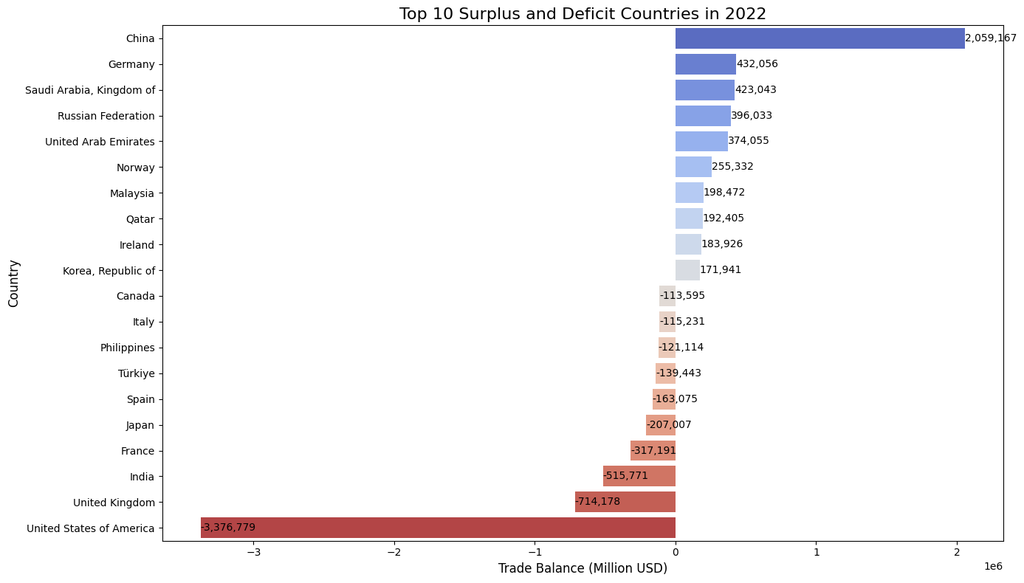

```python
def plot_top_bottom_10(top_10, bottom_10, year):
    plt.figure(figsize=(14, 8))

    # Merge top and bottom data using pd.concat instead of append
    combined = pd.concat([top_10, bottom_10])

    # Sort by TradeBalance to have surplus and deficit clearly separated
    combined = combined.sort_values('TradeBalance', ascending=False)

    # Plotting
    sns.barplot(x='TradeBalance', y='Country', data=combined, palette='coolwarm')

    # Title and labels
    plt.title(f'Top 10 Surplus and Deficit Countries in {year}', fontsize=16)
    plt.xlabel('Trade Balance (Million USD)', fontsize=12)
    plt.ylabel('Country', fontsize=12)

    # Add data labels
    for index, value in enumerate(combined['TradeBalance']):
        plt.text(value, index, f'{value:,.0f}', va='center')

    # Show plot
    plt.tight_layout()
    plt.show()

# Call the function to plot for the year 2022
plot_top_bottom_10(top_10_2022, bottom_10_2022, 2022)
```

```python
top_10_2018, bottom_10_2018 = top_bottom_10_countries(trade_balance, 2018)

print("Top 10 countries with highest trade surplus in 2018:")
print(top_10_2018)
print("\nTop 10 countries with highest trade deficit in 2018:")
print(bottom_10_2018)
```

```
Top 10 countries with highest trade surplus in 2018:
                       Country  Year  TradeBalance
1186                     China  2018     1032959.0
2092                   Germany  2018      831492.0
3123        Korea, Republic of  2018      463112.0
4987  Saudi Arabia, Kingdom of  2018      305491.0
4765        Russian Federation  2018      187245.0
2927                     Japan  2018      163626.0
4031               Netherlands  2018      160104.0
3734                    Mexico  2018      143725.0
2755                   Ireland  2018      126234.0
3514                  Malaysia  2018      107765.0

Top 10 countries with highest trade deficit in 2018:
                       Country  Year  TradeBalance
4348                  Pakistan  2018      -78689.0
5341                     Spain  2018      -94026.0
1727                     Egypt  2018      -96885.0
4563               Philippines  2018     -107638.0
266                  Australia  2018     -131816.0
1057                    Canada  2018     -153067.0
1988                    France  2018     -178880.0
2583                     India  2018     -343466.0
6097            United Kingdom  2018     -441317.0
6140  United States of America  2018    -2719599.0
```

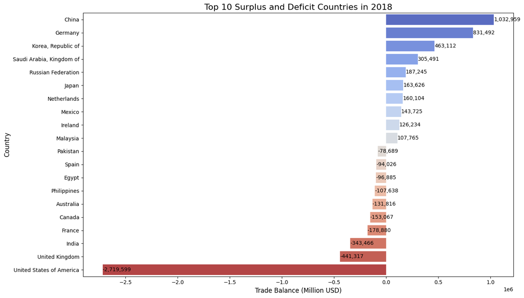

```python
# Call the function to plot for the year 2018
plot_top_bottom_10(top_10_2018, bottom_10_2018, 2018)
```

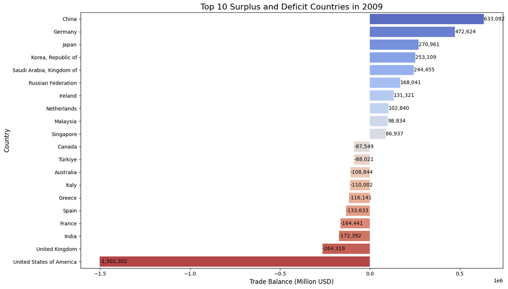

```python
# Call the function to plot for the year 2009
top_10_2009, bottom_10_2009 = top_bottom_10_countries(trade_balance, 2009)
plot_top_bottom_10(top_10_2009, bottom_10_2009, 2009)
```

### 2. How have the trade balances of major trading nations evolved from 1980 to 2022?

#### Let's define major trading nations as the top 10 countries by total trade volume (Volume is both Export imports combined)

```python
total_trade = df_countries.groupby('Country')['Value'].sum().sort_values(ascending=False)
major_nations = total_trade.head(10).index.tolist()
major_nations_balance = trade_balance[trade_balance['Country'].isin(major_nations)]
```

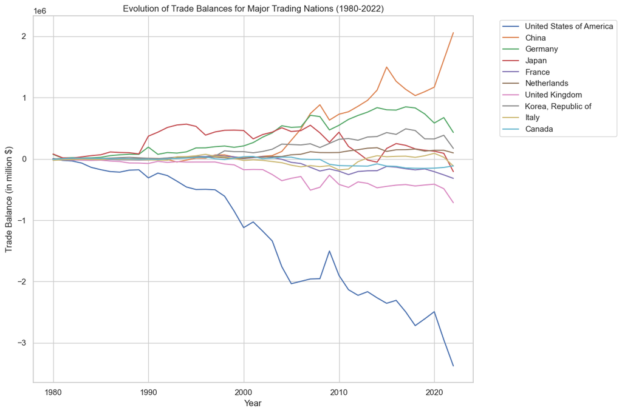

```python
plt.figure(figsize=(12, 8))
for country in major_nations:
    country_data = major_nations_balance[major_nations_balance['Country'] == country]
    plt.plot(country_data['Year'], country_data['TradeBalance'], label=country)

plt.title('Evolution of Trade Balances for Major Trading Nations (1980-2022)')
plt.xlabel('Year')
plt.ylabel('Trade Balance (in million $)')
plt.legend(bbox_to_anchor=(1.05, 1), loc='upper left')
plt.tight_layout()
plt.show()
```

### 3. Which product categories contribute most to trade surpluses or deficits for different countries?

```python
def product_contribution_to_balance(df, year):
    year_data = df[df['Year'] == year]
    balance_by_product = year_data.pivot_table(
        values='Value', index=['Country', 'Product'], columns='Indicator', aggfunc='sum'
    ).reset_index()
    balance_by_product['TradeBalance'] = balance_by_product['Exports'] - balance_by_product['Imports']
    return balance_by_product.sort_values('TradeBalance', ascending=False)
```

```python
product_balance_2022 = product_contribution_to_balance(df_countries_complete, 2022)
top_5_countries = total_trade.head().index.tolist()
for country in top_5_countries:
    country_data = product_balance_2022[product_balance_2022['Country'] == country]
    print(f"\nTop 5 products contributing to trade surplus for {country} in 2022:")
    print(country_data.head())
    print(f"\nTop 5 products contributing to trade deficit for {country} in 2022:")
    print(country_data.tail())
```

```
Top 5 products contributing to trade surplus for United States of America in 2022:
Indicator                   Country  \
2729       United States of America
2730       United States of America
2731       United States of America
2738       United States of America
2723       United States of America

Indicator                                        Product  Exports  Imports  \
2729                                               Fuels   378408   322636
2730                           Fuels and mining products   440955   411282
2731       Integrated circuits and electronic components    60129    61928
2738                                            Textiles    13775    39223
2723                               Agricultural products   222163   259754

Indicator  TradeBalance
2729              55772
2730              29673
2731              -1799
2738             -25448
2723             -37591

Top 5 products contributing to trade deficit for United States of America in 2022:
Indicator                   Country                            Product  \
2724       United States of America                Automotive products
2739       United States of America                Transport equipment
2735       United States of America       Office and telecom equipment
2733       United States of America  Machinery and transport equipment
2734       United States of America                       Manufactures

Indicator  Exports  Imports  TradeBalance
2724        137707   327408       -189701
2739        169126   396631       -227505
2735        157323   419401       -262078
2733        584525  1323925       -739400
2734       1196290  2567260      -1370970

Top 5 products contributing to trade surplus for China in 2022:
Indicator Country                                          Product  Exports  \
555         China                                     Manufactures  3329069
```

[output cut: 101 more lines]

```

Top 5 products contributing to trade deficit for France in 2022:
Indicator Country                            Product  Exports  Imports  \
913        France       Office and telecom equipment    23067    43622
911        France  Machinery and transport equipment   200732   241468
907        France                              Fuels    24023    95352
908        France          Fuels and mining products    39799   115585
912        France                       Manufactures   463501   551964

Indicator  TradeBalance
913              -20555
911              -40736
907              -71329
908              -75786
912              -88463
```

```python
product_balance_2022
```

| Indicator | Country | Product | Exports | Imports | TradeBalance |
| --- | --- | --- | --- | --- | --- |
| 555 | China | Manufactures | 3329069 | 1455054 | 1874015 |
| 554 | China | Machinery and transport equipment | 1671115 | 904548 | 766567 |
| 2227 | Saudi Arabia, Kingdom of | Fuels and mining products | 333009 | 19092 | 313917 |
| 2125 | Russian Federation | Fuels and mining products | 323037 | 9390 | 313647 |
| 2226 | Saudi Arabia, Kingdom of | Fuels | 326289 | 13575 | 312714 |
| ... | ... | ... | ... | ... | ... |
| 1275 | Japan | Fuels and mining products | 43938 | 323089 | -279151 |
| 550 | China | Fuels | 64329 | 535291 | -470962 |
| 2733 | United States of America | Machinery and transport equipment | 584525 | 1323925 | -739400 |
| 551 | China | Fuels and mining products | 118679 | 885910 | -767231 |
| 2734 | United States of America | Manufactures | 1196290 | 2567260 | -1370970 |

2854 rows × 5 columns

[output not shown]

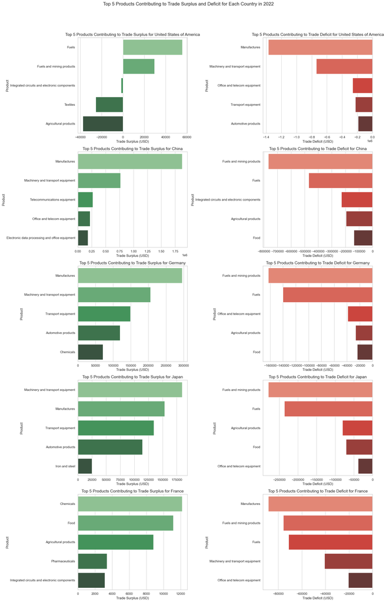

```python
# Plotting settings
sns.set(style="whitegrid")
fig, axes = plt.subplots(len(top_5_countries), 2, figsize=(18, 30))
fig.suptitle('Top 5 Products Contributing to Trade Surplus and Deficit for Each Country in 2022', fontsize=16)

# Plotting for each country
for i, country in enumerate(top_5_countries):
    country_data = product_balance_2022[product_balance_2022['Country'] == country]

    # Top 5 products contributing to trade surplus
    surplus_data = country_data.head(5)
    sns.barplot(
        x='TradeBalance', y='Product', data=surplus_data, ax=axes[i, 0], palette='Greens_d'
    )
    axes[i, 0].set_title(f'Top 5 Products Contributing to Trade Surplus for {country}', fontsize=14)
    axes[i, 0].set_xlabel('Trade Surplus (USD)')
    axes[i, 0].set_ylabel('Product')

    # Top 5 products contributing to trade deficit
    deficit_data = country_data.tail(5).sort_values('TradeBalance')  # Sort to show the largest deficits at the top
    sns.barplot(
        x='TradeBalance', y='Product', data=deficit_data, ax=axes[i, 1], palette='Reds_d'
    )
    axes[i, 1].set_title(f'Top 5 Products Contributing to Trade Deficit for {country}', fontsize=14)
    axes[i, 1].set_xlabel('Trade Deficit (USD)')
    axes[i, 1].set_ylabel('Product')

plt.tight_layout(rect=[0, 0.03, 1, 0.95])  # Adjust layout to fit the title
plt.show()
```

### 4. How has the composition of exports and imports (by product categories) changed for individual countries over the years?

```python
def product_composition_over_time(df, country):
    country_data = df[df['Country'] == country]
    composition = country_data.pivot_table(
        values='Value', index=['Year', 'Product'], columns='Indicator', aggfunc='sum'
    ).reset_index()
    return composition
```

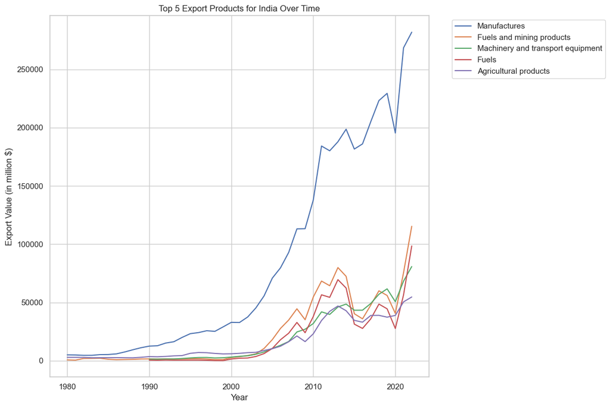

```python
# Plot top 5 export products for India over time
India_composition = product_composition_over_time(df_countries, 'India')
top_5_exports = India_composition.groupby('Product')['Exports'].sum().nlargest(5).index.tolist()
plt.figure(figsize=(12, 8))
for product in top_5_exports:
    product_data = India_composition[India_composition['Product'] == product]
    plt.plot(product_data['Year'], product_data['Exports'], label=product)

plt.title('Top 5 Export Products for India Over Time')
plt.xlabel('Year')
plt.ylabel('Export Value (in million $)')
plt.legend(bbox_to_anchor=(1.05, 1), loc='upper left')
plt.tight_layout()
plt.show()
```

### 5. Which countries have shown the most significant shifts in their trade balance over time, and in which product categories?

```python
def trade_balance_shift(df):
    balance = calculate_trade_balance(df)
    early_period = balance[balance['Year'].between(1980, 1990)].groupby('Country')['TradeBalance'].mean()
    late_period = balance[balance['Year'].between(2012, 2022)].groupby('Country')['TradeBalance'].mean()
    shift = (late_period - early_period).sort_values(ascending=False)
    return shift

balance_shift = trade_balance_shift(df_countries_complete)
```

```python
print("Top 10 countries with the largest positive shift in trade balance:")
print(balance_shift.head(10))
print("\nTop 10 countries with the largest negative shift in trade balance:")
print(balance_shift.tail(100))
```

```
Top 10 countries with the largest positive shift in trade balance:
Country
China                       1.257735e+06
Germany                     6.709190e+05
Korea, Republic of          3.561159e+05
Saudi Arabia, Kingdom of    2.124095e+05
Netherlands                 1.409963e+05
Ireland                     1.339727e+05
Mexico                      1.275155e+05
Qatar                       1.173858e+05
Malaysia                    1.050607e+05
Singapore                   1.018165e+05
Name: TradeBalance, dtype: float64

Top 10 countries with the largest negative shift in trade balance:
Country
Paraguay      -10602.272727
Cyprus        -10654.909091
Austria       -11710.727273
Sudan         -12104.563636
El Salvador   -12868.363636
                   ...
Uzbekistan              NaN
Vanuatu                 NaN
Viet Nam                NaN
Yemen                   NaN
Zambia                  NaN
Name: TradeBalance, Length: 100, dtype: float64
```

```python
balance_shift.loc['Colombia':'Albania']
```

```
Country
Colombia                   -4.587509e+04
Greece                     -5.146618e+04
Philippines                -5.619309e+04
Spain                      -5.841982e+04
Pakistan                   -6.146127e+04
Brazil                     -6.455855e+04
Chile                      -6.547309e+04
Egypt                      -7.620027e+04
Türkiye                    -1.090523e+05
Australia                  -1.260175e+05
Canada                     -1.320610e+05
France                     -1.800272e+05
India                      -2.693347e+05
United Kingdom             -4.212569e+05
United States of America   -2.403411e+06
Afghanistan                          NaN
Albania                              NaN
Name: TradeBalance, dtype: float64
```

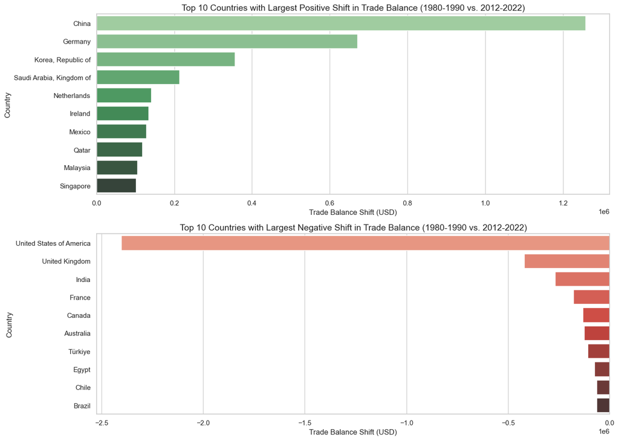

```python
sns.set(style="whitegrid")
plt.figure(figsize=(14, 10))

# Plot for the top 10 countries with positive trade balance shifts
plt.subplot(2, 1, 1)
top_positive_shift = balance_shift.head(10)
sns.barplot(x=top_positive_shift.values, y=top_positive_shift.index, palette='Greens_d')
plt.title('Top 10 Countries with Largest Positive Shift in Trade Balance (1980-1990 vs. 2012-2022)', fontsize=14)
plt.xlabel('Trade Balance Shift (USD)')
plt.ylabel('Country')

# Plot for the top 10 countries with negative trade balance shifts
plt.subplot(2, 1, 2)
top_negative_shift = balance_shift.loc['Brazil':'United States of America'].sort_values()  # Sorting to show the largest negative shifts at the top
sns.barplot(x=top_negative_shift.values, y=top_negative_shift.index, palette='Reds_d')
plt.title('Top 10 Countries with Largest Negative Shift in Trade Balance (1980-1990 vs. 2012-2022)', fontsize=14)
plt.xlabel('Trade Balance Shift (USD)')
plt.ylabel('Country')

plt.tight_layout()
plt.show()
```

### 6. Are there any countries that have consistently maintained trade surpluses or deficits across all product categories?

```python
def consistent_trade_balance(df):
    balance = df.pivot_table(values='Value', index=['Country', 'Year', 'Product'],
                             columns='Indicator', aggfunc='sum').reset_index()
    balance['TradeBalance'] = balance['Exports'] - balance['Imports']

    # Check if all trade balances are positive (surplus) or negative (deficit)
    consistent_surplus = balance.groupby('Country').apply(lambda x: (x['TradeBalance'] > 0).all())
    consistent_deficit = balance.groupby('Country').apply(lambda x: (x['TradeBalance'] < 0).all())

    return consistent_surplus[consistent_surplus], consistent_deficit[consistent_deficit]

consistent_surplus, consistent_deficit = consistent_trade_balance(df_countries_complete)

print("Countries with consistent trade surplus across all products and years:")
print(consistent_surplus)
print("\nCountries with consistent trade deficit across all products and years:")
print(consistent_deficit)
```

```
Countries with consistent trade surplus across all products and years:
Series([], dtype: bool)

Countries with consistent trade deficit across all products and years:
Country
Chad    True
dtype: bool
```

- Chad is the only country with continuous trade deficit

### 7. How do trade balances vary across different product categories for the same country?

```python
def trade_balance_by_product(df, country):
    country_data = df[df['Country'] == country]
    balance = country_data.pivot_table(values='Value', index=['Year', 'Product'],
                                       columns='Indicator', aggfunc='sum').reset_index()
    balance['TradeBalance'] = balance['Exports'] - balance['Imports']
    return balance.groupby('Product')['TradeBalance'].mean().sort_values(ascending=False)
```

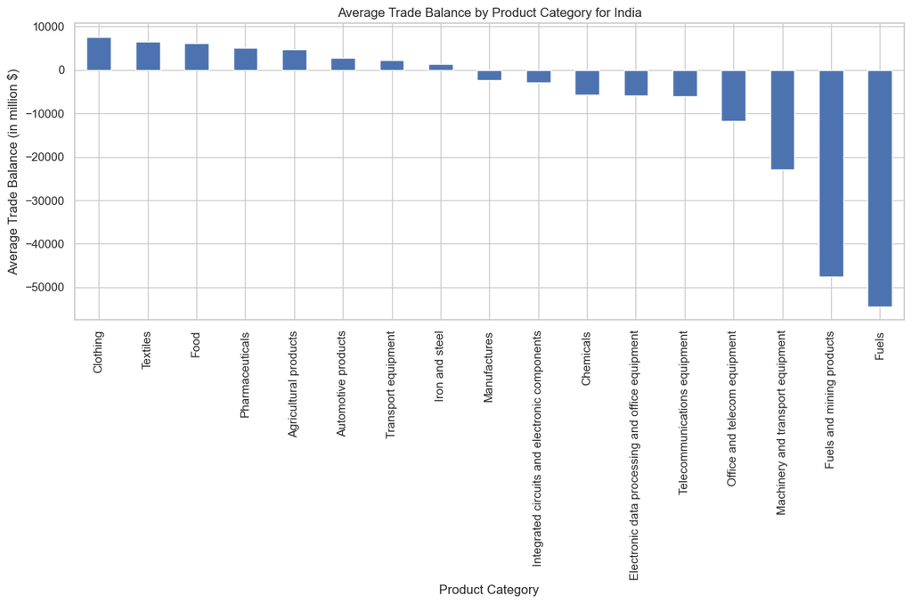

```python
India_balance = trade_balance_by_product(df_countries_complete, 'India')

plt.figure(figsize=(12, 8))
India_balance.plot(kind='bar')
plt.title('Average Trade Balance by Product Category for India')
plt.xlabel('Product Category')
plt.ylabel('Average Trade Balance (in million $)')
plt.xticks(rotation=90)
plt.tight_layout()
plt.show()
```

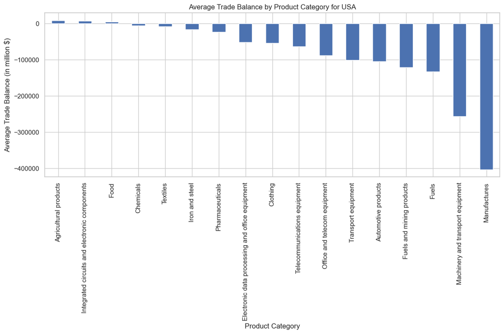

```python
USA_balance = trade_balance_by_product(df_countries_complete, 'United States of America')

plt.figure(figsize=(12, 8))
USA_balance.plot(kind='bar')
plt.title('Average Trade Balance by Product Category for USA')
plt.xlabel('Product Category')
plt.ylabel('Average Trade Balance (in million $)')
plt.xticks(rotation=90)
plt.tight_layout()
plt.show()
```

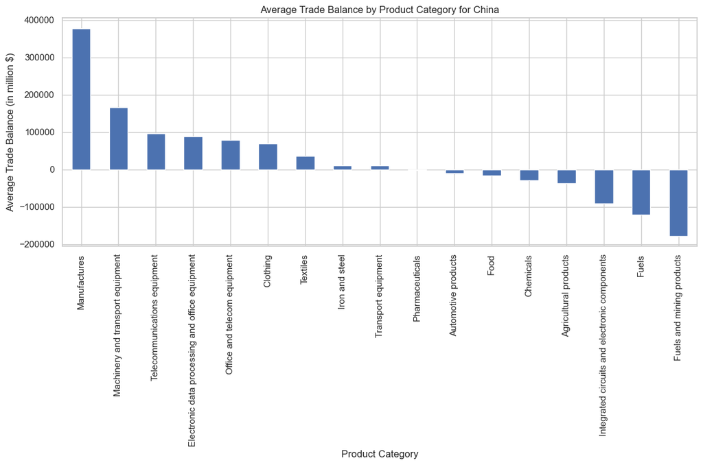

```python
China_balance = trade_balance_by_product(df_countries_complete, 'China')

plt.figure(figsize=(12, 8))
China_balance.plot(kind='bar')
plt.title('Average Trade Balance by Product Category for China')
plt.xlabel('Product Category')
plt.ylabel('Average Trade Balance (in million $)')
plt.xticks(rotation=90)
plt.tight_layout()
plt.show()
```

### 8. Which countries have the most diverse export and import portfolios, and how has this impacted their overall trade balance?

```python
def calculate_diversity_and_balance(df):
    # Calculate Herfindahl-Hirschman Index (HHI) for export and import diversity
    hhi = df.pivot_table(values='Value', index=['Country', 'Year'],
                         columns=['Indicator', 'Product'], aggfunc='sum').fillna(0)

    hhi_export = ((hhi['Exports'] / hhi['Exports'].sum(axis=1).values.reshape(-1, 1)) ** 2).sum(axis=1)
    hhi_import = ((hhi['Imports'] / hhi['Imports'].sum(axis=1).values.reshape(-1, 1)) ** 2).sum(axis=1)

    diversity = pd.DataFrame({
        'ExportDiversity': 1 - hhi_export,
        'ImportDiversity': 1 - hhi_import
    }).reset_index()

    # Calculate overall trade balance
    balance = df.pivot_table(values='Value', index=['Country', 'Year'],
                             columns='Indicator', aggfunc='sum').reset_index()
    balance['TradeBalance'] = balance['Exports'] - balance['Imports']

    # Merge diversity and balance
    result = pd.merge(diversity, balance, on=['Country', 'Year'])
    return result.groupby('Country').mean().sort_values('ExportDiversity', ascending=False)
```

```python
diversity_balance = calculate_diversity_and_balance(df_countries_complete)

print("Top 10 countries with most diverse export portfolios and their trade balances:")
print(diversity_balance[['ExportDiversity', 'ImportDiversity', 'TradeBalance']].head(10))
```

```
Top 10 countries with most diverse export portfolios and their trade balances:
                 ExportDiversity  ImportDiversity  TradeBalance
Country
Tuvalu                  1.000000         0.710803     -8.833333
Chad                    1.000000         0.000000     -2.000000
Georgia                 0.861822         0.862790  -7443.777778
Kyrgyz Republic         0.851002         0.852265  -5244.920000
Lithuania               0.846665         0.846959  -8522.266667
Belarus                 0.841918         0.851022  -8839.851852
Viet Nam                0.835485         0.827819   1517.769231
Malaysia                0.834898         0.791928  56922.255814
Greece                  0.832859         0.805778 -48152.209302
Bulgaria                0.829507         0.832954 -11806.033333
```

### 9. How did major global events (e.g., 2008 financial crisis) impact trade balances for different countries?

```python
def trade_balance_around_event(df, event_year, window=2):
    balance = df.pivot_table(values='Value', index=['Country', 'Year'],
                             columns='Indicator', aggfunc='sum').reset_index()
    balance['TradeBalance'] = balance['Exports'] - balance['Imports']

    pre_event = balance[(balance['Year'] >= event_year - window) & (balance['Year'] < event_year)]
    post_event = balance[(balance['Year'] >= event_year) & (balance['Year'] <= event_year + window)]

    pre_avg = pre_event.groupby('Country')['TradeBalance'].mean()
    post_avg = post_event.groupby('Country')['TradeBalance'].mean()

    impact = (post_avg - pre_avg).sort_values(ascending=False)
    return impact
```

```python
crisis_impact = trade_balance_around_event(df_countries_complete, 2008)

print("Top 10 countries with improved trade balance after 2008 financial crisis:")
print(crisis_impact.head(10))
print("\nTop 10 countries with worsened trade balance after 2008 financial crisis:")
print(crisis_impact.tail(10))
```

```
Top 10 countries with improved trade balance after 2008 financial crisis:
Country
United States of America             192292.333333
China                                134892.166667
Spain                                 84998.333333
Saudi Arabia, Kingdom of              60380.166667
Qatar                                 37452.000000
Ireland                               29128.333333
Kazakhstan                            27757.500000
Switzerland                           22781.833333
Venezuela, Bolivarian Republic of     17642.833333
Hungary                               17483.500000
Name: TradeBalance, dtype: float64

Top 10 countries with worsened trade balance after 2008 financial crisis:
Country
Canada                              -61631.166667
India                               -72856.166667
France                              -81221.500000
Brazil                              -85005.833333
Japan                              -128201.500000
Afghanistan                                   NaN
Angola                                        NaN
Cuba                                          NaN
Lao People's Democratic Republic              NaN
Myanmar                                       NaN
Name: TradeBalance, dtype: float64
```

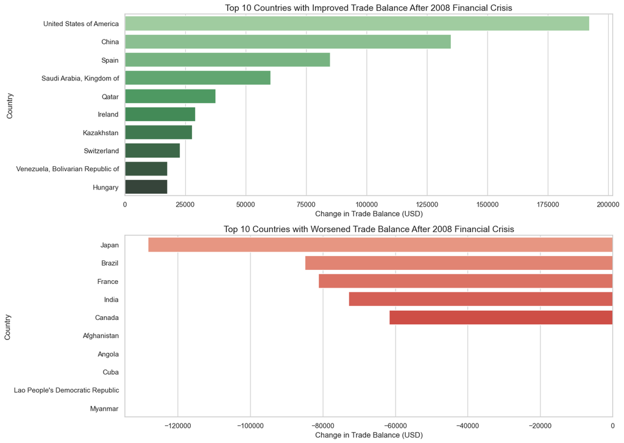

```python
sns.set(style="whitegrid")
plt.figure(figsize=(14, 10))

# Top 10 countries with improved trade balance after 2008
plt.subplot(2, 1, 1)
top_improved = crisis_impact.head(10)
sns.barplot(x=top_improved.values, y=top_improved.index, palette='Greens_d')
plt.title('Top 10 Countries with Improved Trade Balance After 2008 Financial Crisis', fontsize=14)
plt.xlabel('Change in Trade Balance (USD)')
plt.ylabel('Country')

# Top 10 countries with worsened trade balance after 2008
plt.subplot(2, 1, 2)
top_worsened = crisis_impact.tail(10).sort_values()  # Sort to show the largest negative impacts at the top
sns.barplot(x=top_worsened.values, y=top_worsened.index, palette='Reds_d')
plt.title('Top 10 Countries with Worsened Trade Balance After 2008 Financial Crisis', fontsize=14)
plt.xlabel('Change in Trade Balance (USD)')
plt.ylabel('Country')

# Adjust layout for better spacing
plt.tight_layout()
plt.show()
```

### 10. Are there any noticeable trends in trade balances for specific product categories across multiple countries?

```python
def product_trade_balance_trend(df):
    balance = df.pivot_table(values='Value', index=['Year', 'Product'],
                             columns='Indicator', aggfunc='sum').reset_index()
    balance['TradeBalance'] = balance['Exports'] - balance['Imports']

    trends = balance.groupby('Product').apply(lambda x: pd.Series({
        'StartBalance': x.loc[x['Year'].idxmin(), 'TradeBalance'],
        'EndBalance': x.loc[x['Year'].idxmax(), 'TradeBalance'],
        'OverallTrend': x['TradeBalance'].diff().mean()
    }))

    return trends.sort_values('OverallTrend', ascending=False)
```

```python
product_trends = product_trade_balance_trend(df_countries_complete)

print("Product categories with the most positive trade balance trends:")
print(product_trends.head())
print("\nProduct categories with the most negative trade balance trends:")
print(product_trends.tail())
```

```
Product categories with the most positive trade balance trends:
                     StartBalance  EndBalance  OverallTrend
Product
Clothing                  -7872.0     54943.0   1495.595238
Textiles                   2964.0     31635.0    682.642857
Transport equipment       21050.0     40069.0    576.333333
Fuels                    -57904.0    -56857.0     31.727273
Iron and steel             9780.0     -8840.0   -490.000000

Product categories with the most negative trade balance trends:
                                               StartBalance  EndBalance  \
Product
Chemicals                                           21248.0   -161825.0
Integrated circuits and electronic components        1424.0   -244311.0
Office and telecom equipment                         4208.0   -368094.0
Manufactures                                        17845.0   -399434.0
Machinery and transport equipment                  108235.0   -397665.0

                                               OverallTrend
Product
Chemicals                                      -5547.666667
Integrated circuits and electronic components  -7446.515152
Office and telecom equipment                   -8864.333333
Manufactures                                   -9935.214286
Machinery and transport equipment             -12045.238095
```

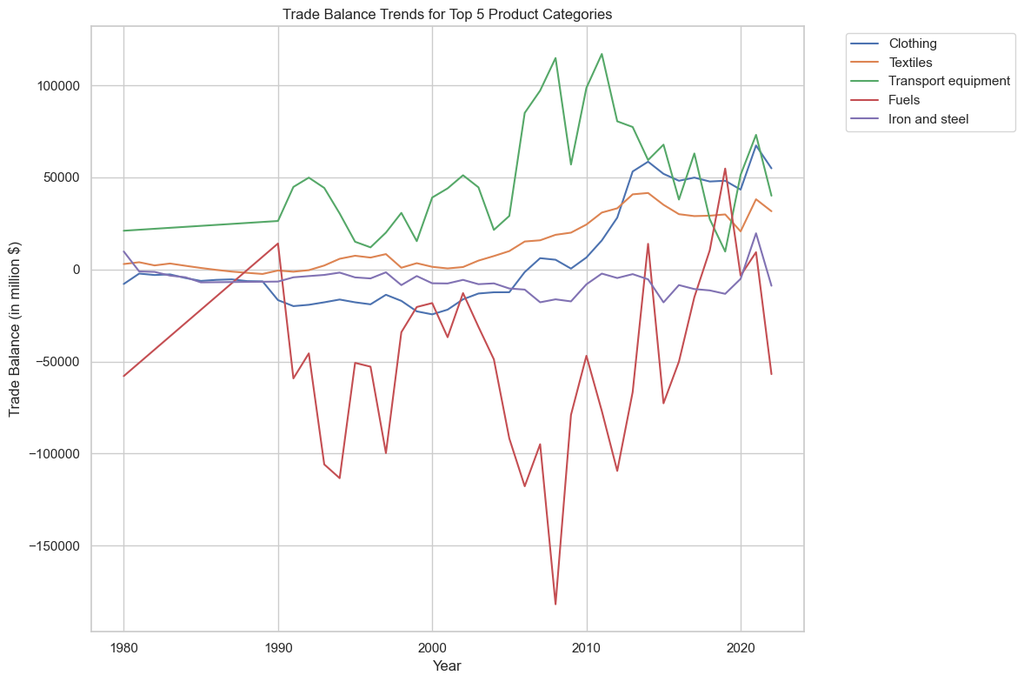

```python
top_5_products = product_trends.head().index

plt.figure(figsize=(12, 8))
for product in top_5_products:
    product_data = df_countries_complete[df_countries_complete['Product'] == product]
    yearly_balance = product_data.pivot_table(values='Value', index='Year',
                                              columns='Indicator', aggfunc='sum').reset_index()
    yearly_balance['TradeBalance'] = yearly_balance['Exports'] - yearly_balance['Imports']
    plt.plot(yearly_balance['Year'], yearly_balance['TradeBalance'], label=product)

plt.title('Trade Balance Trends for Top 5 Product Categories')
plt.xlabel('Year')
plt.ylabel('Trade Balance (in million $)')
plt.legend(bbox_to_anchor=(1.05, 1), loc='upper left')
plt.tight_layout()
plt.show()
```

```python
plt.style.use('seaborn')
colors = plt.cm.viridis(np.linspace(0, 1, 10))
```

### 11. How do trade patterns of special administrative regions (e.g., Hong Kong, Macau) compare in terms of volume and product mix?

```python
def compare_special_regions(df, regions):
    region_data = df[df['Country'].isin(regions)]

    # Total trade volume over time
    volume_over_time = region_data.groupby(['Country', 'Year', 'Indicator'])['Value'].sum().unstack(level='Indicator')
    volume_over_time['Total'] = volume_over_time['Exports'] + volume_over_time['Imports']

    # Product mix for the most recent year
    recent_year = region_data['Year'].max()
    product_mix = region_data[region_data['Year'] == recent_year].groupby(['Country', 'Product', 'Indicator'])['Value'].sum().unstack(level='Indicator')
    product_mix['Total'] = product_mix['Exports'] + product_mix['Imports']

    return volume_over_time, product_mix

special_regions = ['Hong Kong, China', 'Macao, China']
volume_over_time, product_mix = compare_special_regions(df_special_complete, special_regions)
```

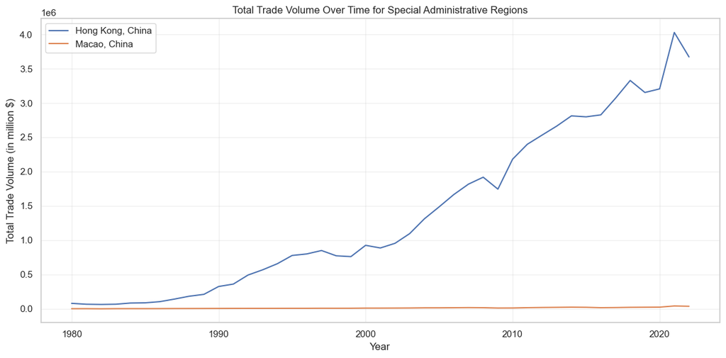

```python
plt.figure(figsize=(12, 6))
for region in special_regions:
    plt.plot(volume_over_time.loc[region].index, volume_over_time.loc[region]['Total'], label=region)
plt.title('Total Trade Volume Over Time for Special Administrative Regions')
plt.xlabel('Year')
plt.ylabel('Total Trade Volume (in million $)')
plt.legend()
plt.grid(True, alpha=0.3)
plt.tight_layout()
plt.show()
```

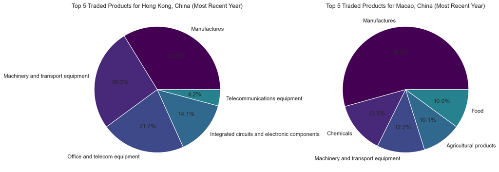

```python
colors = plt.cm.viridis(np.linspace(0, 1, 10))
plt.figure(figsize=(14, 8))
for i, region in enumerate(special_regions):
    plt.subplot(1, 2, i+1)
    top_products = product_mix.loc[region].nlargest(5, 'Total')
    plt.pie(top_products['Total'], labels=top_products.index, autopct='%1.1f%%', colors=colors)
    plt.title(f'Top 5 Traded Products for {region} (Most Recent Year)')
plt.tight_layout()
plt.show()
```

### 12. What were the trade volumes of entities before and after major geopolitical changes?

```python
def trade_volume_around_event(df, entity, event_year, window=5):
    entity_data = df[df['Country'] == entity]
    event_data = entity_data[(entity_data['Year'] >= event_year - window) & (entity_data['Year'] <= event_year + window)]

    volume_by_year = event_data.groupby(['Year', 'Indicator'])['Value'].sum().unstack(level='Indicator')
    volume_by_year['Total'] = volume_by_year['Exports'] + volume_by_year['Imports']

    return volume_by_year
```

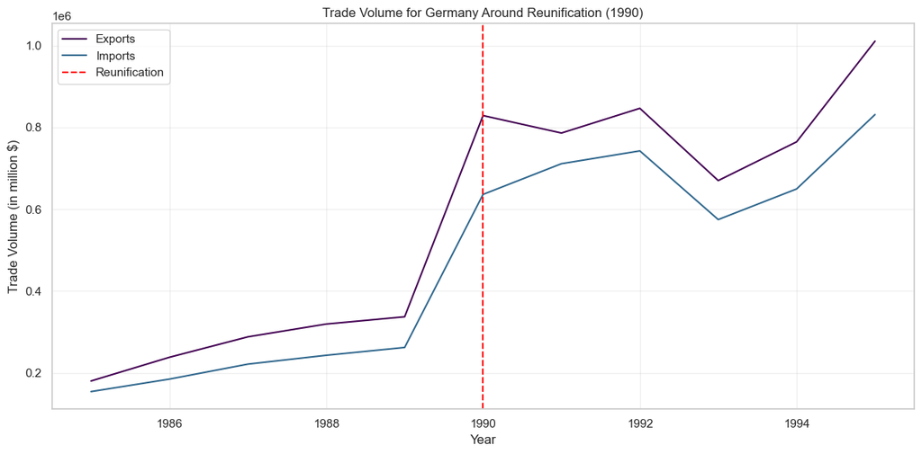

```python
# Example: Trade volume for Germany around reunification (1990)
germany_trade = trade_volume_around_event(df_countries_complete, 'Germany', 1990)

plt.figure(figsize=(12, 6))
plt.plot(germany_trade.index, germany_trade['Exports'], label='Exports', color=colors[0])
plt.plot(germany_trade.index, germany_trade['Imports'], label='Imports', color=colors[3])
plt.axvline(x=1990, color='red', linestyle='--', label='Reunification')
plt.title('Trade Volume for Germany Around Reunification (1990)')
plt.xlabel('Year')
plt.ylabel('Trade Volume (in million $)')
plt.legend()
plt.grid(True, alpha=0.3)
plt.tight_layout()
plt.show()
```

### 13. How have trade patterns evolved for economic unions like the EU compared to individual member states?

```python
def compare_union_to_members(df_union, df_members, union_name, member_countries):
    union_data = df_union[df_union['Country'] == union_name]
    members_data = df_members[df_members['Country'].isin(member_countries)]

    union_trade = union_data.groupby(['Year', 'Indicator'])['Value'].sum().unstack(level='Indicator')
    members_trade = members_data.groupby(['Year', 'Indicator'])['Value'].sum().unstack(level='Indicator')

    union_trade['Total'] = union_trade['Exports'] + union_trade['Imports']
    members_trade['Total'] = members_trade['Exports'] + members_trade['Imports']

    return union_trade, members_trade
```

```python
eu_members = ['Germany', 'France', 'Italy', 'Spain', 'Netherlands','United Kingdom','Poland','Sweden','Switzerland','Belgium']  # powerful EU members
eu_trade, eu_members_trade = compare_union_to_members(df_special_complete, df_countries_complete, 'European Union', eu_members)
```

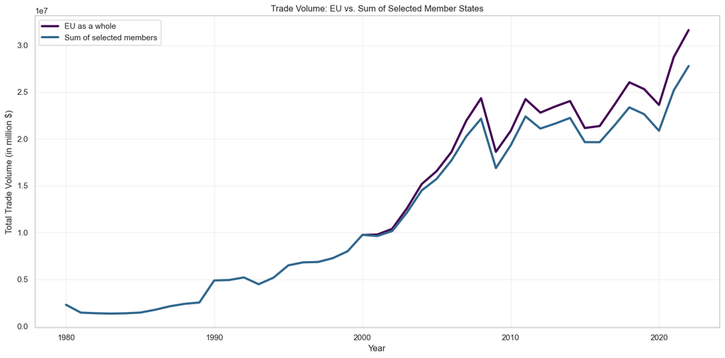

```python
plt.figure(figsize=(14, 7))
plt.plot(eu_trade.index, eu_trade['Total'], label='EU as a whole', color=colors[0], linewidth=3)
plt.plot(eu_members_trade.index, eu_members_trade['Total'], label='Sum of selected members', color=colors[3], linewidth=3)
plt.title('Trade Volume: EU vs. Sum of Selected Member States')
plt.xlabel('Year')
plt.ylabel('Total Trade Volume (in million $)')
plt.legend()
plt.grid(True, alpha=0.3)
plt.tight_layout()
plt.show()
```

### 14. Do overseas territories show distinct trade patterns compared to sovereign nations?

```python
def compare_territories_to_nations(df_territories, df_nations):
    territories_data = df_territories.groupby(['Country', 'Year', 'Indicator'])['Value'].sum().unstack(level='Indicator')
    nations_data = df_nations.groupby(['Country', 'Year', 'Indicator'])['Value'].sum().unstack(level='Indicator')

    territories_data['TradeBalance'] = territories_data['Exports'] - territories_data['Imports']
    nations_data['TradeBalance'] = nations_data['Exports'] - nations_data['Imports']

    territories_avg = territories_data.groupby('Country').mean()
    nations_avg = nations_data.groupby('Country').mean()

    return territories_avg, nations_avg
```

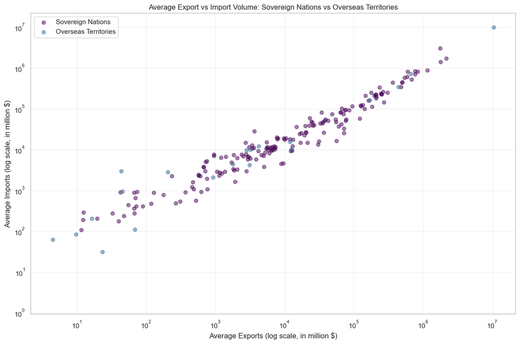

```python
territories_avg, nations_avg = compare_territories_to_nations(df_special_complete, df_countries_complete)

plt.figure(figsize=(12, 8))
plt.scatter(nations_avg['Exports'], nations_avg['Imports'], alpha=0.5, label='Sovereign Nations', color=colors[0])
plt.scatter(territories_avg['Exports'], territories_avg['Imports'], alpha=0.5, label='Overseas Territories', color=colors[3])
plt.xscale('log')
plt.yscale('log')
plt.title('Average Export vs Import Volume: Sovereign Nations vs Overseas Territories')
plt.xlabel('Average Exports (log scale, in million $)')
plt.ylabel('Average Imports (log scale, in million $)')
plt.legend()
plt.grid(True, alpha=0.3)
plt.tight_layout()
plt.show()
```

### 15. How has the relative importance of special economic zones in global trade changed over time?

```python
def special_zones_importance(df_special, df_countries):
    special_trade = df_special.groupby(['Year', 'Indicator'])['Value'].sum().unstack(level='Indicator')
    global_trade = df_countries.groupby(['Year', 'Indicator'])['Value'].sum().unstack(level='Indicator')

    special_trade['Total'] = special_trade['Exports'] + special_trade['Imports']
    global_trade['Total'] = global_trade['Exports'] + global_trade['Imports']

    relative_importance = (special_trade['Total'] / global_trade['Total']) * 100

    return relative_importance
```

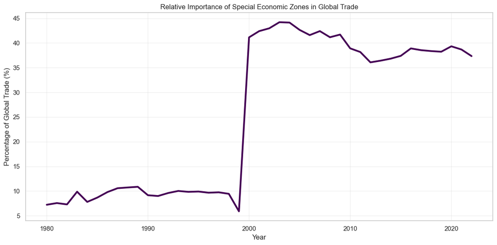

```python
relative_importance = special_zones_importance(df_special_complete, df_countries_complete)

plt.figure(figsize=(12, 6))
plt.plot(relative_importance.index, relative_importance.values, color=colors[0], linewidth=3)
plt.title('Relative Importance of Special Economic Zones in Global Trade')
plt.xlabel('Year')
plt.ylabel('Percentage of Global Trade (%)')
plt.grid(True, alpha=0.3)
plt.tight_layout()
plt.show()
```

### 16. How do the types and volumes of products traded by countries compare to those of special entities?

```python
def compare_product_trade(df_countries, df_special):
    countries_product_trade = df_countries.groupby('Product')['Value'].sum()
    special_product_trade = df_special.groupby('Product')['Value'].sum()

    combined_trade = pd.DataFrame({
        'Countries': countries_product_trade,
        'Special Entities': special_product_trade
    }).fillna(0)

    combined_trade['Countries_Percentage'] = combined_trade['Countries'] / combined_trade['Countries'].sum() * 100
    combined_trade['Special_Percentage'] = combined_trade['Special Entities'] / combined_trade['Special Entities'].sum() * 100

    return combined_trade.sort_values('Countries', ascending=False)
```

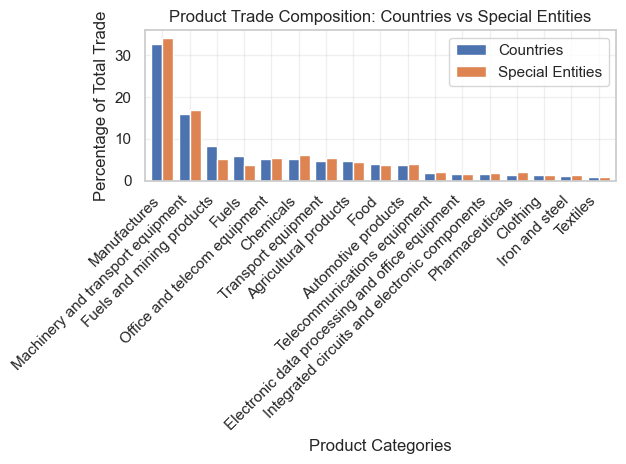

```python
product_comparison = compare_product_trade(df_countries_complete, df_special_complete)

plt.figure(figsize=(14, 8))
product_comparison[['Countries_Percentage', 'Special_Percentage']].plot(kind='bar', width=0.8)
plt.title('Product Trade Composition: Countries vs Special Entities')
plt.xlabel('Product Categories')
plt.ylabel('Percentage of Total Trade')
plt.legend(['Countries', 'Special Entities'])
plt.xticks(rotation=45, ha='right')
plt.grid(True, alpha=0.3)
plt.tight_layout()
plt.show()
```

### 17. Are there significant differences in the trade volume growth rates between countries and special entities?

```python
def compare_growth_rates(df_countries, df_special):
    countries_volume = df_countries.groupby('Year')['Value'].sum()
    special_volume = df_special.groupby('Year')['Value'].sum()

    countries_growth = countries_volume.pct_change()
    special_growth = special_volume.pct_change()

    return countries_growth, special_growth
```

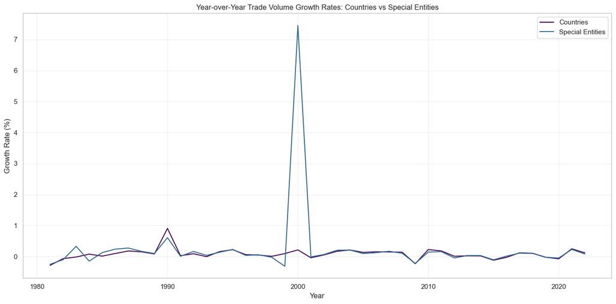

```python
countries_growth, special_growth = compare_growth_rates(df_countries_complete, df_special_complete)

plt.figure(figsize=(14, 7))
plt.plot(countries_growth.index, countries_growth.values, label='Countries', color=colors[0])
plt.plot(special_growth.index, special_growth.values, label='Special Entities', color=colors[3])
plt.title('Year-over-Year Trade Volume Growth Rates: Countries vs Special Entities')
plt.xlabel('Year')
plt.ylabel('Growth Rate (%)')
plt.legend()
plt.grid(True, alpha=0.3)
plt.tight_layout()
plt.show()
```

```python
df_special[(df_special['Year']>1998)&(df_special['Year']<2002)].sort_values(by='Value',ascending=False).head(20)
```

|  | Indicator | Country | Product | Unit | Year | ValueFlag | Value |
| --- | --- | --- | --- | --- | --- | --- | --- |
| 113553 | Exports | European Union | Manufactures | M$ | 2001 | Normal | 1815875 |
| 113627 | Exports | European Union | Manufactures | M$ | 2000 | Normal | 1780548 |
| 14568 | Imports | European Union | Manufactures | M$ | 2000 | Normal | 1615612 |
| 14993 | Imports | European Union | Manufactures | M$ | 2001 | Normal | 1610832 |
| 136628 | Exports | European Union | Machinery and transport equipment | M$ | 2001 | Normal | 949187 |
| 136911 | Exports | European Union | Machinery and transport equipment | M$ | 2000 | Normal | 934027 |
| 43684 | Imports | European Union | Machinery and transport equipment | M$ | 2000 | Normal | 848326 |
| 43310 | Imports | European Union | Machinery and transport equipment | M$ | 2001 | Normal | 832918 |
| 165564 | Exports | European Union | Transport equipment | M$ | 2001 | Normal | 389833 |
| 165647 | Exports | European Union | Transport equipment | M$ | 2000 | Normal | 369539 |
| 73292 | Imports | European Union | Transport equipment | M$ | 2001 | Normal | 316504 |
| 73257 | Imports | European Union | Transport equipment | M$ | 2000 | Normal | 313582 |
| 114572 | Exports | European Union | Chemicals | M$ | 2001 | Normal | 292245 |
| 114586 | Exports | European Union | Chemicals | M$ | 2000 | Normal | 278104 |
| 84635 | Imports | European Union | Fuels and mining products | M$ | 2000 | Normal | 275321 |
| 142913 | Exports | European Union | Automotive products | M$ | 2001 | Normal | 272312 |
| 54964 | Imports | European Union | Office and telecom equipment | M$ | 2000 | Normal | 263918 |
| 142272 | Exports | European Union | Automotive products | M$ | 2000 | Normal | 261788 |
| 84550 | Imports | European Union | Fuels and mining products | M$ | 2001 | Normal | 261480 |
| 20103 | Imports | European Union | Chemicals | M$ | 2001 | Normal | 250981 |

### 18. Top 10 Exporters by value overall

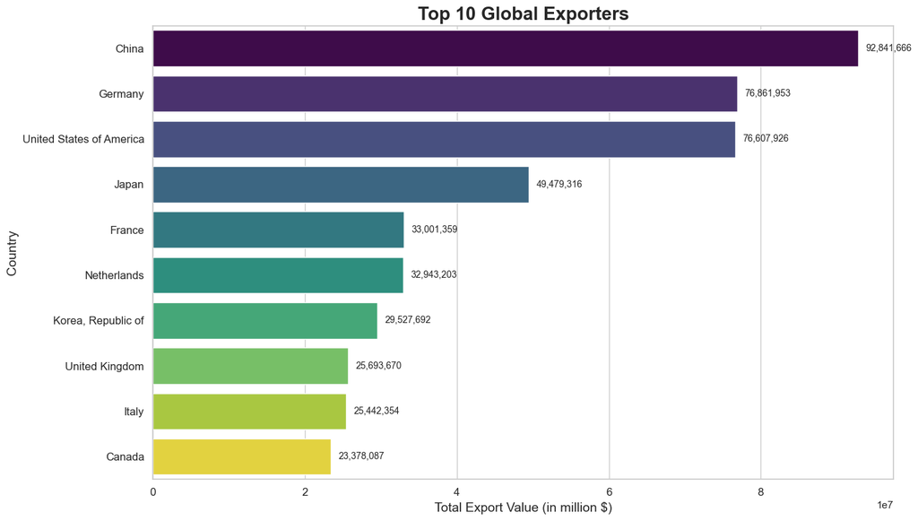

```python
top_exporters = df_countries[df_countries['Indicator'] == 'Exports'].groupby('Country')['Value'].sum().nlargest(10)

plt.figure(figsize=(14, 8))
ax = sns.barplot(x=top_exporters.values, y=top_exporters.index, palette=colors)
plt.title('Top 10 Global Exporters', fontsize=20, fontweight='bold')
plt.xlabel('Total Export Value (in million $)', fontsize=14)
plt.ylabel('Country', fontsize=14)
plt.tick_params(axis='both', which='major', labelsize=12)
for i, v in enumerate(top_exporters.values):
    ax.text(v + 1000000, i, f'{v:,.0f}', va='center', fontsize=10)

plt.tight_layout()
plt.show()
```

### 19. Top 10 Importers by value overall

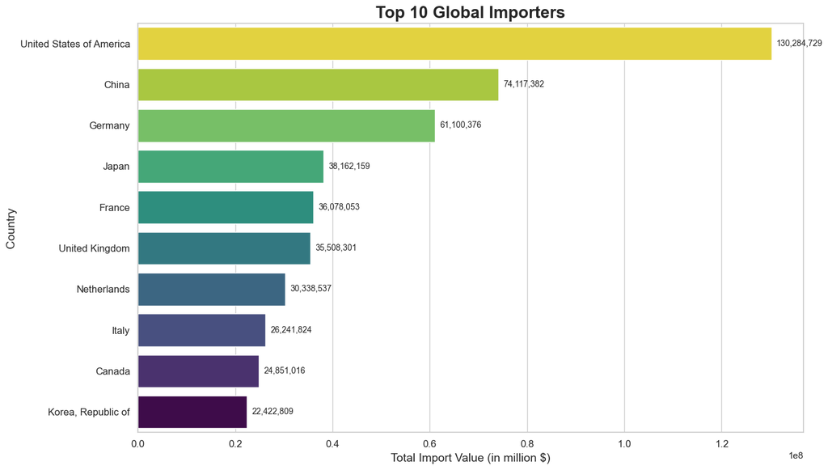

```python
top_importers = df_countries[df_countries['Indicator'] == 'Imports'].groupby('Country')['Value'].sum().nlargest(10)

plt.figure(figsize=(14, 8))
ax = sns.barplot(x=top_importers.values, y=top_importers.index, palette=colors[::-1])  # Reverse color palette
plt.title('Top 10 Global Importers', fontsize=20, fontweight='bold')
plt.xlabel('Total Import Value (in million $)', fontsize=14)
plt.ylabel('Country', fontsize=14)
plt.tick_params(axis='both', which='major', labelsize=12)

# Add value labels to the bars
for i, v in enumerate(top_importers.values):
    ax.text(v + 1000000, i, f'{v:,.0f}', va='center', fontsize=10)

plt.tight_layout()
plt.show()
```

### 20. Top 5 importers and exporters of Textiles

```python
textiles_data = df_countries_complete[df_countries_complete['Product'] == 'Textiles']

top_textile_exporters = textiles_data[textiles_data['Indicator'] == 'Exports'].groupby('Country')['Value'].sum().nlargest(5)
top_textile_importers = textiles_data[textiles_data['Indicator'] == 'Imports'].groupby('Country')['Value'].sum().nlargest(5)
```

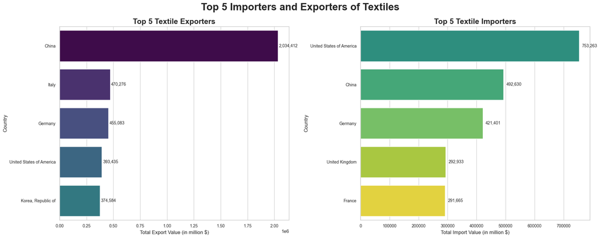

```python
fig, (ax1, ax2) = plt.subplots(1, 2, figsize=(20, 8))
# Top 5 Textile Exporters
sns.barplot(x=top_textile_exporters.values, y=top_textile_exporters.index, palette=colors[:5], ax=ax1)
ax1.set_title('Top 5 Textile Exporters', fontsize=18, fontweight='bold')
ax1.set_xlabel('Total Export Value (in million $)', fontsize=12)
ax1.set_ylabel('Country', fontsize=12)
ax1.tick_params(axis='both', which='major', labelsize=10)

for i, v in enumerate(top_textile_exporters.values):
    ax1.text(v + 10000, i, f'{v:,.0f}', va='center', fontsize=10)

# Top 5 Textile Importers
sns.barplot(x=top_textile_importers.values, y=top_textile_importers.index, palette=colors[5:], ax=ax2)
ax2.set_title('Top 5 Textile Importers', fontsize=18, fontweight='bold')
ax2.set_xlabel('Total Import Value (in million $)', fontsize=12)
ax2.set_ylabel('Country', fontsize=12)
ax2.tick_params(axis='both', which='major', labelsize=10)

for i, v in enumerate(top_textile_importers.values):
    ax2.text(v + 10000, i, f'{v:,.0f}', va='center', fontsize=10)

plt.suptitle('Top 5 Importers and Exporters of Textiles', fontsize=24, fontweight='bold')
plt.tight_layout()
plt.show()
```